# Whole Foods vs. Cracker Barrel

A famous proxy, rebuilt from scratch: the metric reproduces, and then does not survive being asked about people

84-355 Democracy’s Data

August 2026

On a Saturday in September 2011, David Wasserman stood in the Cracker Barrel in Manassas, Virginia, and counted the pickup trucks in the parking lot. Then he drove twenty-six miles east to the Whole Foods in Clarendon and counted the Priuses. The column he wrote for the *Washington Post* proposed that the 2012 election would be fought between those two parking lots. It carried a number that has been quoted ever since:

> In 2008, candidate Barack Obama carried 81 percent of counties with a Whole Foods and just 36 percent of counties with a Cracker Barrel — a record 45-point gap.

Fifteen years later the metric is a fixture. It appears in election-night commentary, in explainers about the diploma divide, in a hundred versions of the same map. It is easy to state, easy to check, and it sounds like it is about culture.

This chapter rebuilds it from nothing, with its own store list, its own returns and its own point-in-polygon, and asks two questions in order. **Does it replicate?** It does, closely. **Does it mean what it is used to mean?** That is a different question with a different answer.

## The half of this metric that is not a public fact

The returns are the easy half. This book has already spent two chapters on where county presidential returns come from and what it costs to assemble them, and this build reads the same compilation the rest of Part II reads.

The store list is the problem. **Neither company publishes where its stores are.**

Cracker Barrel is a public company, so it files something. Its 2025 annual report says, in one sentence in Item 1:

> As of September 12, 2025, we operated 657 Cracker Barrel stores in 43 states.

That is a count. It is not a list, and it has no addresses in it. Whole Foods does not even produce the count: it has been a subsidiary of Amazon since 2017, it files no separate report, and Amazon’s own filings do not break out store locations. The number of Whole Foods Markets in the United States is not a published figure. It is an estimate, and the firms that sell the estimate do not agree with each other.

| Source | Brand | Stores | As of | What it is |
| --- | --- | --- | --- | --- |
| Cracker Barrel 10-K (FY2025) | Cracker Barrel | 657 | 12 Sep 2025 | SEC filing |
| OpenStreetMap, this build | Cracker Barrel | 647 | 14 Aug 2026 | volunteer survey |
| ScrapeHero | Whole Foods Market | 537 | 15 Jul 2026 | commercial tracker |
| storelocators.com | Whole Foods Market | 517 | Aug 2026 | commercial tracker |
| Statista / company reporting | Whole Foods Market | 570 | 2025 | commercial tracker |

Both chains run a store locator, and both locators are JavaScript applications that a script cannot read. This is not a paywall or a permission problem; it is plumbing, and it is invisible. Four routes were tried on 13 August 2026:

```
crackerbarrel.com/sitemap.xml       200   a sitemap with no location URLs in it
crackerbarrel.com/api/store/search  404   whose body is a 220 KB web page
locations.crackerbarrel.com/<any>   200   the same 267 KB shell for every path
wholefoodsmarket.com/stores         200   an empty React container
```

Three of the four report success. The fourth reports failure and returns a perfectly valid web page anyway. A script that checked the status code would have accepted three of these and a script that checked whether it got HTML back would have accepted all four.

So the inventory used here is **OpenStreetMap** — every object in the United States tagged with the brand’s Wikidata identifier, pulled through Overpass. That is a file maintained by volunteers. It is a real limitation, and it is also the point worth sitting with: *the input to a famous political metric is a crowd-sourced guess at a private fact.* It gives **532 Whole Foods Markets** and **647 Cracker Barrels**.

The query matches on `brand:wikidata` rather than on the name. Names are typed by hand by thousands of people: *Whole Foods*, *Whole Foods Market*, *WholeFoods*, *Whole Foods Market 365*. A name match silently drops whichever spellings nobody anticipated.

### Auditing the volunteers against the filing

One of the two brands can be checked, and only one, which is itself the finding. Against Cracker Barrel’s own 10-K the volunteer file holds up: **647 of 657 stores, 98.5%.**

The state count does not. OpenStreetMap places Cracker Barrels in **44 states** and the company says **43**, so at least one store on the map is not a store. The discrepancy resolves to a specific restaurant. Maine’s only Cracker Barrel, on Maine Mall Road in South Portland, **closed permanently in January 2025**, eight months before the filing date. It is still on the map today. Its OSM object is also the only one of the 8 single-store states carrying no `website` tag, which is the sort of tell that is obvious afterwards and invisible before.

Nothing equivalent can be done for Whole Foods, because there is no filing to check it against. The commercial trackers in the table above span 517 to 570, a spread of about ten percent, and none of them shows its work.

## The metric replicates

Before testing a number it is worth establishing that you can produce it. This build’s store list was captured in **August 2026**; Wasserman’s figures for 2020 were published in **December 2020**, from a store list five and a half years older. Recomputing his four categories with today’s stores:

| Counties with | How many | Wasserman published | This file recomputes | Difference |
| --- | --- | --- | --- | --- |
| whole foods only | 95 | 95% | 94.7% | -0.3 |
| both | 116 | 77% | 75.9% | -1.1 |
| cracker barrel only | 363 | 18% | 17.4% | -0.6 |
| neither | 2538 | 12% | 11.7% | -0.3 |

**Every category lands within about a point.** The same holds going further back. For 2008 the op-ed reports **81% and 36%**, a 45-point gap, and this file recomputes 78.2% and 34.9%, a **43.3-point gap** — a drift of 1.7 points across fifteen years of store openings and closings.

That is a stronger result than it looks. It means the volunteer store list, the county assignment and the returns are all doing what they should, and it means **nothing that follows can be blamed on the data.** Whatever is wrong with this metric is not a measurement problem.

> **Before you read on, commit to two numbers.** In 2024 the Democratic candidate carried some share of counties containing a Whole Foods and some share of counties containing a Cracker Barrel. **How many percentage points apart are those two shares?** Then the same question asked of *people* rather than of counties: take every vote cast in Whole Foods counties and every vote cast in Cracker Barrel counties, and compute the Democratic share of the two-party vote in each. **How many points apart are those?** Write both down before you turn the page.

## Fifty points, or eleven

| 2024, measured in | Whole Foods counties | Cracker Barrel counties | Gap |
| --- | --- | --- | --- |
| counties carried | 76.9% | 26.5% | 50.4 points |
| votes cast | 59.4% | 48.6% | 10.8 points |

Measured the way the metric is always measured, **one county and one tally**, the divide is enormous and has grown: 43 points in 2008, **50 points in 2024.**

Measured in people, the same two groups of counties are **10.8 points apart**, and that number has barely moved in sixteen years.

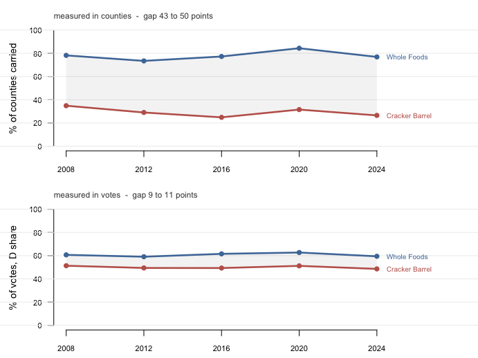

The metric on two different units, 2008-2024. Counties above, votes below. Hover any year.

**Figure 1. The same metric on two units.** The top panel is the published version: the share of *counties* carried, which is what every retelling of this statistic reports. The bottom panel is the same counties, the same elections and the same store list, with the Democratic share of the *two-party vote* in place of the count of counties. The shaded band is the gap. It is the difference between the panels that this chapter is about.

## Why the two panels disagree

Nothing has been done to the data between the panels. The disagreement comes from a fact about American counties that the metric’s arithmetic quietly assumes away.

| Counties with | How many | Share of all counties | D carried | Share of all votes | D share of votes |
| --- | --- | --- | --- | --- | --- |
| whole foods only | 96 | 3.1% | 90.6% | 24.1% | 65.5% |
| both | 116 | 3.7% | 65.5% | 27.8% | 54.2% |
| cracker barrel only | 363 | 11.6% | 14.0% | 17.9% | 39.9% |
| neither | 2,546 | 81.6% | 9.4% | 30.2% | 37.4% |

Read the third and fifth columns against each other.

**The counties with neither store are 82% of all counties and 30% of all votes.** They are the largest single block of the American electorate, they are the most Republican group in the table, and **the metric does not have a column for them.** Whatever the Whole Foods–Cracker Barrel gap is measuring, it is measuring it on the 18% of counties where one of two specific companies chose to open.

The second reason is the definition. Wasserman’s own rule, stated explicitly when he published the four categories, is that **a county with both stores counts in both columns.** With 116 such counties out of 3,121, that is nearly harmless when the unit is counties. It is not harmless when the unit is votes. Those 116 counties are the big metros, and they cast 28% of the national vote. They appear at full weight on *both sides* of the subtraction.

Take the overlap out and compare the exclusive categories: **65.5% to 39.9%**, a 25.6-point gap. That is a real and large difference. It is half the county figure, and it describes 42% of the electorate rather than all of it.

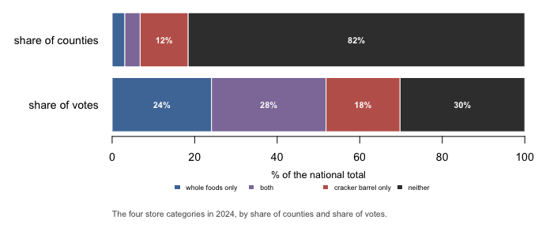

The four store categories in 2024, by share of counties and share of votes. Hover any block.

**Figure 2. Counties are not people.** The same four categories measured two ways. The dark block is the counties with neither store: about four-fifths of the counties, and about a third of the votes. Counties with only a Cracker Barrel are 12% of counties and 18% of votes. Counties with only a Whole Foods are the reverse: 3% of counties and 24% of votes.

## Cracker Barrel country is not rural

The folk reading of the metric is that Whole Foods stands for the urban professional and Cracker Barrel for rural America. The first half is right. The second is wrong, and the file says so plainly.

| Counties with | Median population | Median people per square mile | Median % with a BA |
| --- | --- | --- | --- |
| whole foods only | 586,346 | 1,458 | 44% |
| both | 586,614 | 970 | 39% |
| cracker barrel only | 122,546 | 239 | 26% |
| neither | 19,722 | 33 | 20% |

Rural America is the dark block in Figure 2, the 2,546 counties with neither store, and it is more Republican than Cracker Barrel country is. The Democratic candidate carried 9.4% of those counties, against 14.0% of Cracker Barrel counties. The chain that is supposed to symbolise the rural Republican vote marks counties that are *less* Republican than the ones it skipped.

## Does the store tell you anything a census tract would not?

The metric’s appeal is that it feels like it is measuring culture — taste, identity, what people eat. A cheaper explanation is available: Whole Foods opens where there are dense, affluent, highly educated customers, and those are the people who vote Democratic. On that account the store is not a cultural signal at all. It is a demographic variable wearing a logo.

The two accounts make different predictions, and they can be told apart. Take the 212 counties selected by “has a Whole Foods”. Then take the 212 counties selected by rules that use no store data at all, matched to the same count, and ask the identical question of each.

| The 212 counties picked by | D carried | D share of their votes | That also have a Whole Foods |
| --- | --- | --- | --- |
| has a Whole Foods | 76.9% | 59.4% | 100% |
| the 212 densest counties | 74.5% | 59.9% | 64% |
| the 212 most-educated counties | 71.7% | 61.5% | 50% |
| the 212 most populous counties | 63.7% | 57.5% | 74% |

**On counties the store list wins by about two points.** On votes it loses: density and education both pick a set of counties whose electorate is *more* Democratic than the Whole Foods set. And the last column shows why the contest is so close — 64% of the densest 212 counties have a Whole Foods in them. The store list is substantially a density list with a brand name on it.

This is exactly what the company said in 2011, when the *Post* asked. Cracker Barrel’s spokeswoman told Wasserman that **“politics don’t play any role in our site selection process.”** She was telling the truth, and the truth is the problem: the stores are sited on traffic counts, rooftops and household income. That is *why* they line up with the vote, and it is why they add so little once you have the income and the rooftops.

## What had to be decided before any of this could be counted

Four things in this build are judgements rather than lookups, and each of them changed a published number.

**Connecticut is two different maps.** The state abolished its counties as statistical units and the census replaced them with nine planning regions. The 2024 returns are published on the new shapes and the four earlier elections on the old ones. Assigning stores against a single vintage put all 13 Connecticut stores in units that four of the five elections have never heard of. It did so silently, because a failed join produces a zero, and a zero is a perfectly valid store count.

Uncorrected, this file reported that Connecticut contained no Whole Foods county until 2024. It contained four all along.

The assignment is now done twice, once per vintage, and 13 stores land in different units depending on which map you use. **All 13 are in Connecticut.**

**Washington is eight rows in 2024 and one row before it.** The compilation reports the District by ward from 2024 onward. Wards are not counties, the census publishes no county population for them, and no boundary file contains them. So all 8 of the District’s Whole Foods landed in the single county polygon, which the 2024 returns call Ward 1. Left alone, the capital would have entered this chapter as a 40,000-vote county that the Republican candidate nearly carried. The wards are summed back.

**Shannon County, South Dakota, does not exist.** It was renamed Oglala Lakota in 2015 and given a new FIPS code. The earlier file uses the old code and the later ones use the new, so a naive panel carries two rows for one place, each missing the other’s elections.

**Alaska has no counties at all.** It reports presidential votes by State House district, so there is no county-level return to carry, and every proportion in this chapter is of fifty jurisdictions rather than fifty-one. There are 0 stores of either brand in Alaska, so nothing is lost except the denominator, the bottom number each share is divided by.

None of these is exotic. All four are the ordinary condition of joining two files that were built by different people for different purposes, and all four fail quietly.

## What this chapter cannot tell you

**It cannot tell you that the store list is complete.** It is a volunteer file audited against one company’s filing and nothing at all against the other’s. 98.5% coverage of Cracker Barrel is reassuring. It is not a guarantee that the missing 10 are scattered at random. If volunteers map less thoroughly where fewer volunteers live, the gaps are exactly where the metric is most sensitive.

The chapter cannot rule that out. It can only report that the categories reproduce Wasserman’s published figures to within a point, which would be a coincidence if the gaps were large.

**The matched-count test is a comparison, not a regression**, meaning not a best line drawn through a scatter of points. Showing that density picks a similar set of counties does not establish that the store adds *nothing*. It establishes that whatever it adds is small, compared with the thing everybody already agrees it is standing in for. A proper decomposition would need other columns this file does not carry.

**A store is not a shopper.** Every claim here is about counties containing a store, never about people who shop in one. Wasserman’s headline was about shoppers, and his data, like this data, was about county boundaries. A county is not a customer base, and the two Whole Foods counties either side of a state line share a metro area. This book makes this argument at length in levels-of-aggregation, and this chapter is another instance of it.

**The returns are a compilation.** This build reads the same GitHub file the rest of Part II reads rather than the certified assembly, because one publisher across five elections keeps a source change from masquerading as a trend. On 2024 the two agree closely: 3,098 counties compared, 1 disagreement about who carried the county and 42 about the Democratic vote. What that comparison does and does not settle is the subject of county-returns.

**And it says nothing about 2028.** Every figure here is retrospective. The bellwether chapter is the standing warning about what happens to a county-level regularity when somebody points it at the future.

## What the metric is good for

The Whole Foods–Cracker Barrel gap is not a fraud and it is not sloppy. It replicates to within a point on a store list assembled fifteen years after the column was written, which is more than most political statistics of its fame would survive. As a piece of arithmetic it is sound.

What it is not is a measurement of the country. Read as intended, as *the two Americas are this far apart*, it does four things wrong at once.

The habit worth taking from this is not scepticism about grocery stores. It is a question to ask of any stand-in: **what is it actually made of, and who had to publish it?** Here the answer is that one company files a number with the SEC and the other files nothing, while both hide the addresses. The list everybody uses is maintained by volunteers, who left a closed restaurant in Maine on the map for over a year. The metric survived all of that. The inference did not.

## Sources

**Data**

- OpenStreetMap contributors. Store locations for Whole Foods Market (`brand:wikidata=Q1809448`) and Cracker Barrel (`brand:wikidata=Q4492609`), all United States objects, retrieved through the Overpass API on 14 August 2026. Licensed under the Open Database Licence. The two query URLs, their retrieval dates and their content hashes are recorded in this chapter’s `PROVENANCE.tsv`; the responses themselves are kept, because the same query does not return the same answer twice. The API is open and needs no key. https://overpass-api.de/api/interpreter and https://www.openstreetmap.org/
- Cracker Barrel Old Country Store, Inc. *Annual Report on Form 10-K for the fiscal year ended 1 August 2025.* Item 1, store and state counts as of 12 September 2025. https://investor.crackerbarrel.com/static-files/881c3ef3-0a78-4e60-9fc8-6d2a340bdbc8
- McGovern, Tony. *US County Level Presidential Results 2008–2024.* https://github.com/tonmcg/US_County_Level_Election_Results_08-24. Used for all five elections, and checked for 2024 against the certified state returns assembled in county-returns.
- U.S. Census Bureau. *2024 and 2020 Cartographic Boundary Files*, counties, for the two geographies each election is published on; *2024 Gazetteer Files*, counties, for land area; *Vintage 2024 Population Estimates*, counties. https://www2.census.gov/geo/tiger/GENZ2024/shp/cb_2024_us_county_500k.zip, https://www2.census.gov/geo/tiger/GENZ2020/shp/cb_2020_us_county_500k.zip, https://www2.census.gov/geo/docs/maps-data/data/gazetteer/2024_Gazetteer/2024_Gaz_counties_national.zip and https://www2.census.gov/programs-surveys/popest/datasets/2020-2024/counties/totals/co-est2024-alldata.csv
- U.S. Department of Agriculture, Economic Research Service. *County-level Data Sets: Education*, share of adults 25 and over with a bachelor’s degree or higher, 2018–22. https://ers.usda.gov/sites/default/files/_laserfiche/DataFiles/48747/Education.csv
- The 10-K’s two figures and the published percentages transcribed from Wasserman are the only numbers in this chapter typed in by hand.

**The data itself**

Every figure above is drawn from these tables. They are plain CSV, they open in a spreadsheet, and they are yours to take further.

`alternatives.csv`, `anachronism.csv`, `categories.csv`, `gap.csv`, `inventory_check.csv`, `published_2020.csv`

**Your turn**

None of these is answered above, and every one can be answered from the tables you just opened.

- `gap.csv` has `gap_counties` and `gap_votes` for each year. The two tell different stories. Which one is the metric usually quoted as, and which describes the electorate?
- `categories.csv` gives `med_density`, `med_pop` and `med_ba` for each category of county. Is Cracker Barrel country actually rural, or just not urban?
- `alternatives.csv` swaps in other rules for classifying counties, with `overlap_wf_pct`. Find a rule that does about as well. What was the original metric really measuring?
- `inventory_check.csv` compares the store count from a company filing against the count from the open map. Work out the discrepancy. Which source would you cite?

**The journalism this chapter tests**

- Wasserman, David. “Will the 2012 election be a contest of Whole Foods vs. Cracker Barrel shoppers?” *Washington Post*, 28 September 2011. The source of the 2008 figures and of the Cracker Barrel spokeswoman’s remark.
- Wasserman, David [@Redistrict]. Four-category breakdown of the 2020 result, 8 December 2020. The source of the published figures in the replication table.

**On the closed restaurant**

- Hoey, Dennis. “Maine’s only Cracker Barrel closes in South Portland.” *Portland Press Herald*, 21 January 2025.

Rebuild this data yourself, with an AI assistant

[output not shown]